Clinical and Translational Radiation Oncology 35 (2022) 44–55

Available online 4 May 2022

2405-6308/© 2022 The Authors. Published by Elsevier B.V. on behalf of European Society for Radiotherapy and Oncology. This is an open access article under the

CC BY-NC-ND license (http://creativecommons.org/licenses/by-nc-nd/4.0/).

Review Article

Blood-brain barrier permeability following conventional photon

radiotherapy – A systematic review and meta-analysis of clinical and

preclinical studies

Elvin’t Hart <sup>a</sup><sup>,</sup><sup>1</sup>, Zelda Od´e <sup>a</sup><sup>,</sup><sup>1</sup>, Marc P.P. Derieppe <sup>a</sup>, Lucianne Groenink <sup>b</sup>, Martijn W. Heymans <sup>c</sup>,

Ren´e Otten <sup>d</sup>, Maarten H. Lequin <sup>e</sup>, Geert O.R. Janssens <sup>f</sup>, Eelco W. Hoving <sup>a</sup>,

Dannis G. van Vuurden <sup>a</sup><sup>,</sup><sup>1</sup><sup>,</sup>*

a *Princess M*´*axima Center for Pediatric Oncology, Heidelberglaan 25, 3584 CS Utrecht, The Netherlands*

b *Division of Pharmacology, Utrecht Institute for Pharmaceutical Sciences, Utrecht University, The UMC Utrecht Brain Center, Utrecht, Universiteitsweg 99, 3584 CG*

*Utrecht, The Netherlands*

c *Department of Epidemiology and Data Science, Amsterdam University Medical Center, De Boelelaan 1089a, 1081 HV Amsterdam, The Netherlands*

d *University Library, Vrije Universiteit Amsterdam, De Boelelaan 1105, 1081 HV Amsterdam, The Netherlands*

e *Department of Radiology, University Medical Center Utrecht, Heidelberglaan 100, 3584 CX Utrecht, The Netherlands*

f *Department of Radiotherapy, University Medical Center Utrecht, Heidelberglaan 100, 3584 CX Utrecht, The Netherlands*

A R T I C L E I N F O

*Keywords:*

Blood-brain barrier

Radiotherapy

Permeability

Dose Fractionation

Radiotherapy Dosage

A B S T R A C T

Radiotherapy (RT) is a cornerstone treatment strategy for brain tumours. Besides cytotoxicity, RT can cause

disruption of the blood–brain barrier (BBB), resulting in an increased permeability into the surrounding brain

parenchyma. Although this effect is generally acknowledged, it remains unclear how and to what extent different

radiation schemes affect BBB integrity. The aim of this systematic review and meta-analysis is to investigate the

effect of photon RT regimens on BBB permeability, including its reversibility, in clinical and preclinical studies.

We systematically reviewed relevant clinical and preclinical literature in PubMed, Embase, and Cochrane search

engines. A total of 69 included studies (20 clinical, 49 preclinical) were qualitatively and quantitatively analysed

by meta-analysis and evaluated on key determinants of RT-induced BBB permeability in different disease types

and RT protocols. Qualitative data synthesis showed that 35% of the included clinical studies reported BBB

disruption following RT, whereas 30% were inconclusive. Interestingly, no compelling differences were observed

between studies with different calculated biological effective doses based on the fractionation schemes and

cumulative doses; however, increased BBB disruption was noted during patient follow-up after treatment.

Qualitative analysis of preclinical studies showed RT BBB disruption in 78% of the included studies, which was

significantly confirmed by meta-analysis (p *<* 0.01). Of note, a high risk of bias, publication bias and a high

heterogeneity across the studies was observed. This systematic review and meta-analysis sheds light on the

impact of RT protocols on BBB integrity and opens the discussion for integrating this factor in the decision-

making process of future RT, with better study of its occurrence and influence on concomitant or adjuvant

therapies.

*Abbreviations:* BBB, Blood-brain barrier; RT, Radiotherapy; MRI, Magnetic resonance imaging (MRI); LC-MS, Liquid chromatography-mass spectrometry; CT,

Computed tomography; PET, Positron emission tomography; NMR, Nuclear magnetic resonance; NSCLC, Non-small cell lung cancer; AVM, Arteriovenous malfor-

mations; WBRT, Whole-brain RT; SRS, Stereotactic radiosurgery; EB, Evans Blue.

* Corresponding author.

*E-mail addresses:* e.thart-6@prinsesmaximacentrum.nl (E. Hart), l.groenink@uu.nl (L. Groenink), mw.heymans@amsterdamumc.nl (M.W. Heymans), m.h.

lequin@umcutrecht.nl (M.H. Lequin), g.o.r.janssens@umcutrecht.nl (G.O.R. Janssens), e.w.hoving-3@prinsesmaximacentrum.nl (E.W. Hoving), d.g.vanvuurden@

prinsesmaximacentrum.nl (D.G. van Vuurden).

1 Authors contributed equally to this study.

Contents lists available at ScienceDirect

Clinical and Translational Radiation Oncology

journal homepage: www.sciencedirect.com/journal/clinical-and-translational-radiation-oncology

[figure not shown]

https://doi.org/10.1016/j.ctro.2022.04.013

Received 12 April 2022; Accepted 30 April 2022

*Clinical and Translational Radiation Oncology 35 (2022) 44–55*

45

**Introduction**

Homeostasis of the central nervous system is sustained by the

blood–brain barrier (BBB), also known as the neurovascular unit, that

protects the brain tissue from potential harmful pathogens or sub-

stances. The BBB has a restricted permeability due to being both (1) a

physical barrier formed by tight junctions between the endothelial cells

that are surrounded by pericytes and a basal membrane and (2) a

functional barrier where ATP-binding cassette efflux transporters have

the potential to pump a large spectrum of molecules from the extra-

vascular interstitium back into the blood stream [1]. These anatomical

and functional features result in the exclusion of large substances

(greater than 500 Da) [2] and over 98% of all small molecules from the

brain, amongst which are chemotherapeutics and targeted therapies [3].

Hence, the BBB limits the overall treatment efficacy in brain malig-

nancies because of the reduced, if not absent, drug delivery into the

brain parenchyma [4,5].

Meanwhile, radiotherapy (RT), after maximal safe surgery, is still a

cornerstone for the treatment of brain tumours such as high-grade gli-

omas and diffuse midline gliomas. While conventional photon radiation

therapy has been applied as a treatment modality for roughly 50% of all

cancer patients [6], technological advances, like image-guided RT or

different particle radiations (electron, proton, neutron beams) have

improved the specificity of the treatment modality and enabled better

and precise radiation treatment of the tumours while sparing the healthy

tissue [7]. Despite this technical progress, large volumes of the func-

tioning brain issue have to be radiated due to the highly infiltrative

nature of most primary brain tumours [8]. Due to low radio-sensitivity

of certain tumours [9], often high dosages are needed to achieve the

maximal anti-tumour effect, which also cause damage to the surround-

ing normal tissue. Vascular endothelial cells are one of the most radio-

sensitive cells and consequently the brain vasculature is prone to be

affected by radiation [10].

There is evidence that BBB integrity is altered after the application of

RT leading to both reversible and irreversible tissue damage for the

patient. Whereas early brain damage caused by radiation is mostly

reversible, later, more chronic injuries, manifesting at the earliest three

months after treatment, can cause (sometimes severe) problems for the

patient [11]. It is assumed that cellular and vascular responses of the

BBB upon RT are mediated by astrogliosis and endothelial ultrastruc-

tural changes [12]. These changes to the BBB can eventually lead to

seizures, brain inflammation and leaky vessels causing haemorrhage

and/or stroke [13–15]. Furthermore, it has been postulated that mostly

RT with cumulative doses between 20 and 30 Gy increases BBB

permeability [16], however the actual impact of RT protocols (fractions,

frequency) on BBB integrity remains to be elucidated, in order to support

decision-making with regard to the prevention of toxicity and the use of

concomitant chemotherapeutic therapies. To the best of our knowledge,

there is no clear consensus on to what extent radiation doses and frac-

tionation schemes affect BBB integrity. Subsequently, it is unknown to

what extent confounding factors, such as the patients’ clinical picture,

interplay in the evaluation of RT-induced effects on BBB permeability. In

addition, ascertainment of the kinetics of BBB opening can be helpful to

decide on dosing and timing for drugs that are not expected to cross an

intact BBB.

The aim of this study is therefore to provide a thorough review of

clinical and preclinical studies that have ascertained the effect of con-

ventional photon RT on BBB permeability and its reversibility following

different RT regimens. A systematic review of all available clinical and

preclinical literature was performed, in three different search engines.

Data were processed by qualitative analysis and meta-analysis to sta-

tistically assess the extent of BBB disruption following photon radiation

in comparison to a non-irradiated control group.

**Methodology**

*Data sources and literature search*

A literature search was performed based on the Preferred Reporting

Items for Systematic Reviews and Meta-Analysis (PRISMA)-statement

[17]. To identify all relevant publications, systematic searches in the

bibliographic databases PubMed, Embase, and The Cochrane Library

(via Wiley) were performed on April 24th, 2020, without any re-

strictions on publication date. Search terms were based on two key

words; “Radiotherapy” and “Blood-brain barrier” and included

controlled terms (MeSH in PubMed and Emtree in Embase), as well as

free text terms. The full search strategies for all databases can be found

in the supplementary data, Table S1, S2, and S3.

*Study selection and in- and exclusion criteria*

All abstracts from the search were screened and assessed for their

relevance in this study. Upon inclusion and abstract screening, full ar-

ticles were examined based on the in- and exclusion criteria, see

Table S4. To emphasize, the articles were screened for conventional

photon RT, indicated as “RT” in the rest of the article. For both screening

levels all studies were evaluated by two independent investigators.

*Risk of bias of individual studies and publication bias assessment*

Risk of bias was determined by the Cochrane Risk of Bias tool for the

clinical studies [18] and by the SYRCLE Risk of Bias tool for the pre-

clinical studies [19]. Parameters chosen were based on the objectives of

this review and the characteristics of all included studies. “Other bias”

includes all other potential sources of bias, not included in the pre-

defined parameters. Scoring of the studies was performed by two inde-

pendent investigators until a unanimous result was achieved. Risk of

bias graphs were established by Review Manager 5.3 (The Cochrane

Community, the Nordic Cochrane Centre: Copenhagen, 2014) [20]. To

estimate publication bias, a funnel plot was created in Rstudios [21]

with the Metaviz package [22] and an Eggers test was performed [23].

Possible missing studies were imputed using the trim-and-fill method

[24].

*Data collection*

For the qualitative and quantitative analyses, studies were classified

based on 1) the disease type of the subjects (clinical only), 2) the pre-

clinical model (preclinical only), 3) the type of radiation used, 4) the

biological effective dose (BED) (≤ 50 Gy, 50–100 Gy and ≤ 100 Gy), 5)

the readout technique that measured BBB disruption, and 6) the time-

point(s) which BBB disruption was measured (follow-up time). To allow

for better interstudy comparison and analysis, per study both the RT

fractionation scheme and cumulative radiation dose were used to

calculate the BEDbased on the linear-quadratic formula by Fowler et al

(1989) [25] with an α-β of 3 (patients with solid tumours and animals) or

10 (patients with AVM and leukaemia). The timing of the occurrence of

BBB disruption by RT, described in the clinical studies was classified

based on the radiation injury classification of Greene-Schloesser et al

(2012) [26], as follows: 1) acute effects (within one month), 2) early

delayed effects (within 1–6 months), and 3) late delayed effects (after 6

months of radiation) [26]. For preclinical studies the classification of

Wei et al (2016) and Collins et al (2017) was used: 1) acute effects

(within 4 weeks), 2) early delayed effects (within 4–12 weeks), and (3)

late delayed effects (after 12 weeks) [27,28]. For the quantitative ana-

lyses, data was extracted from the studies either directly or using ImageJ

[29] as a digital ruler for the figures.

*E. Hart et al.*

*Clinical and Translational Radiation Oncology 35 (2022) 44–55*

46

*Statistical analysis*

Analyses were conducted using Review Manager 5.3 software (The

Cochrane Community) [20]. The effect of RT on BBB permeability was

assessed based on continuous variables found in the included studies, as

described in Table S4. Only studies containing a treatment and control

group were eligible for meta-analysis. In the meta-analysis, random-ef-

fect models were applied because of anticipated heterogeneity [30]

between studies with inverse-variance weighting to obtain the summary

effect size. The summary effect measurement was calculated as the

standard mean difference (SMD) with the corresponding 95% confi-

dence interval (CI). Because most studies were composed of multiple

experimental groups, the effect measurement was calculated at group

level (instead of study level). Forest plots were generated based on the

following parameters: 1) animal model, 2) BED, 3) read-out technique of

BBB disruption and 4) follow-up time after radiation for all included

quantitative preclinical studies. Subgroup analysis was applied if groups

contained at least five studies or more. Heterogeneity was calculated by

means of the dispersion index of effect sizes I<sup>2</sup>. Publication bias was

studied using Funnel plots, the Egger method and trim-and-fill analysis.

**Results**

*Search results*

A total of 4883 unique studies were screened, of which 215 studies

deemed eligible (Fig. 1). After full text assessment, 20 clinical studies

and 49 preclinical studies could be included for qualitative analysis. The

meta-analysis encompassed 29 preclinical studies. The remaining 20

preclinical studies were excluded because of missing information

regarding the effect size, group size, or any procedural information.

None of the clinical studies could be included in the meta-analysis, since

none of these studies included randomized control groups.

*Description of the included studies*

The 20 relevant clinical studies were published between 1979 and

2018 (Table 1). Of these 20 studies, four included patients diagnosed

with arteriovenous malformations (AVM) [31–34], four described pa-

tients suffering from haematological cancers [35–38], one focused on

nasopharyngeal cancer [39], six included primary brain tumour patients

tastases of other cancer types [47–50]. The 49 preclinical studies were

published between 1964 and 2019, consisting of different animal

models (Table 2). The majority of the studies, *i.e.*, 27 (55%), investigate

BBB disruption in rats [51–77]. In addition, eleven (22%) studies use

mice [12,78–87], five involve rabbits [88–92], two include dogs

[93,94], two describe monkeys [95,96], one article studied the effects of

RT on the BBB in sharks [97] and one in pigs [98].

*Risk of bias and reported quality*

The risk of bias for individual studies was assessed separately for

clinical and preclinical studies. For clinical studies, a high or unclear risk

of bias was found for seven of the twelve scoring criteria (Fig. S1).

Conversely, a low risk of 75%, 75%, 60% and 55% was scored for the

[figure not shown]

**Fig. 1.** PRISM flow chart of study selection. After selection and filtering of a total of 4883 studies, 215 studies were included in this study, of which 20 clinical studies

were evaluated for inclusion in the subsequent qualitative analysis and no clinical study was suited for meta-analysis. 49 preclinical studies were qualitatively

analysed, of which 29 studies were included in the meta-analysis.

*E. Hart et al.*

*Clinical and Translational Radiation Oncology 35 (2022) 44–55*

47

categories “Incomplete outcome data”, “Selective reporting”, “Reli-

ability of outcome measurements” and “Timing similarity of outcome

assessment” respectively, while no other bias is found. Preclinical

studies were assessed with a high or unclear risk of bias for six of the ten

scoring criteria (Fig. S2). A low risk of bias was assigned in 63%, 63%

and 67% of the studies for the scoring criteria: “Baseline characteristics”,

“Incomplete outcome data” and “Selective outcome reporting”, respec-

tively. Three studies were found to have a high risk of “Other bias” for

the following reasons: 1) “Missing statistics”, 2) “Missing group sizes”,

and 3) “Fluctuating follow-up times”.

*Effect of RT on BBB permeability*

*Clinical data - qualitative analysis*

Of the 20 clinical studies that investigated BBB integrity after RT,

fifteen (75%) were performed in adults, three [32,33,38] (15%) in both

adult and paediatric patients, and two [35,36] (10%) studied the effect

of RT on the BBB in children only (Table 1). Seven out of the 20 studies

(35%) reported alterations of BBB permeability [32,33,39–41,47,50],

six

studies

(30%)

observed

a

shallow

but

unclear

effect

[31,34,42–44,46], whereas seven (35%) do not detect any effect

[35–38,45,48,49] (Fig. 2A).

*Disease type*

Two of the six studies including glioma and two of the four studies

with patients suffering brain metastases observed BBB permeability after

treatment (Fig. 2B). None of the studies in which patients were treated

with RT for a haematological disease reported any alteration of BBB

integrity after treatment. Causal links between the application of radi-

ation and the impact on the BBB in brain tumours and exposed non-

tumour tissue, could not be established because of the design of the

clinical studies.

*Biological effective dose*

In only one of the six studies [47], in which patients were treated

with a BED of ≤ 50 Gy [47], and two of the six studies [41,47] with a

BED of 50–100 Gy, an increase in BBB permeability was observed

(Fig. 2C). Two of these studies, Farjam et al (2015) [41] (yes) and Cao et

al (2009) [44] (unclear), noticed a peak in permeability at 1–1.5

months, which was reversed over time. Interestingly, in both studies

**Table 1**

Clinical studies included in the qualitative synthesis and the key parameters of interest in this review article.

Author, year

Disease type

Type of

radiotherapy

Number

of

fractions

Fraction

dose

Total dose

Biological

Effective

Dose

Readout

technique

Age

Time

BBB

disruption

1

Lim et al,

2018

Supratentorial

glioblastoma

RT

?

?

45 or 61.1

Gy

?

MRI

Adults

4.2

months

Yes

2

Okawa et al,

2018

Brain metastases

(NSCLC)

WBRT

?

?

30 Gy

?

LC-MS

Adults

3 weeks

Yes

3

Teng et al,

2017

Brain metastases

WBRT/SRS

Single,

10 or 15

3 or 2.5

Gy

15, 18, 24,

30, or 37.5

Gy

37.5, 39,

46.9, 50.4 or

81.6

MRI

Adults

1 month

Yes

4

Fang et al,

2015

Brain metastases

(NSCLC)

WBRT

10

3 Gy

30 Gy

39 Gy

LC-MS

Adults

29 days

No

5

Farjam et al,

2015

Low-grade glioma

Conformal or

intensity-

modulated RT

28 – 33

1.8 Gy

50.4–59.4

Gy

59.5–70.1

Gy

MRI

Adults

18

months

Yes

6

Moraes et al,

2015

AVM

RT/SRS

?

?

10–22.5 Gy

?

MRI/CT

Adults

greater

than 6

months

Unclear

7

Parkhutik et

al, 2012

AVM

SRS

Single

dose

–

24 Gy

216 Gy

MRI

Adults

63

months

Unclear

8

Cao et al,

2009

Low-grade glioma

Conformal RT

28 – 33

1.8 Gy

50.4–59.4

Gy

59.5–70.1

Gy

MRI

Adults

6

months

Unclear

9

Matulewicz

et al, 2006

Glioma (high and

low grade)

RT

30

2 Gy

60 Gy

72 Gy

NMR

spectroscopy

Adults

24

months

Unclear

10

Tu et al,

2006

AVM

SRS

Single

dose

–

18–20 Gy

126–153.3

Gy

Electron

microscopy

Adults/

children

64

months

Yes

11

Wu et al,

2006

Glioblastoma

RT

28

1.6 Gy

45 Gy

52.2 Gy

MRI/CT

?

5–10

days

No

12

Cao et al,

2005

High grade glioma

Conformal RT

35

2 Gy

70 Gy

84 Gy

MRI

Adults

6

months

Unclear

13

Levegrün et

al, 2004

AVM

SRS

Single

dose

–

19 Gy

139.3 Gy

MRI

Adults/

children

26.8

months

Yes

14

Chan et al,

1999

Nasopharyngeal

carcinoma

RT

?

?

66–71.2 Gy

?

MRI

Adults

4.4 years

Yes

15

Riccardi et

al, 1998

Acute leukemia

RT

10 or 12

1.8 Gy

18 or 24 Gy

28.8 or 38.4

Gy

LC-MS

Children

24 h

No

16

Ott et al,

1991

Intracranial

lymphoma

RT

?

?

30 or 40 Gy

?

PET

Adults

21

weeks

No

17

Riccardi et

al, 1991

Acute leukemia

RT

?

?

18 or 24 Gy

?

LC-MS

Children

1 year

No

18

Qin et al,

1990

Intracranial

tumors

RT

15 or 20

2 Gy

30 or 40 Gy

36 or 48 Gy

CT

?

8

months

Unclear

19

Jarden et al,

1985

Brain metastases

WBRT

6 or 10

2, 3, or

4/6 Gy

20, or 30 Gy

24, 34 or

44.4 Gy

PET

Adults

72 h

No

20

Seshadri et

al, 1979

Acute leukemia/

non-hodgkin’s

lymphoma

RT

12 or 16

1.5 or 2

Gy

24 Gy

36 or 40 Gy

LC-MS

Adults/

children

48 h

No

**Abbreviations:** NSCLC, non-small cell lung cancer; AVM, arteriovenous malformations; RT, radiotherapy; WBRT, whole-brain RT; SRS, stereotactic radiosurgery; MRI,

magnetic resonance imaging; LC-MS, liquid chromatography mass spectrometry; NMR, nuclear magnetic resonance; CT, computed tomography; PET, positron

emission tomography.

*E. Hart et al.*

*Clinical and Translational Radiation Oncology 35 (2022) 44–55*

48

**Table 2**

Preclinical studies included in the qualitative synthesis and the key parameters of interest in this review article.

Author, year

Preclinical

model

Type of

radiotherapy

Number

of

fractions

Fraction

dose

Total

dose

Biological

Effective

Dose

Readout technique

Time

BBB

disruption

meta-

analysis

1

Jost et al, 2019

Rats

RT

6 fractions

5 Gy

30 Gy

45 Gy

MRI

2 days

Yes

Yes

2

Yoshida et al,

2018

Mice

RT

Single

dose

–

60 Gy

420 Gy

EB extravasation

1 week

Unclear

Yes

3

Constanzo et

al, 2017

Rats

Gamma knife

RT

Single

dose

–

10, 37,

or 100

Gy

20, 173.9,

1100 Gy

MRI

140

days

Yes

Yes

4

Kalm et al,

2017

Mice

RT

Single

dose

–

8 Gy

14.4 Gy

Radioactive brain

uptake

72 h

Yes

Yes

5

Zhou et al,

2017

Rats

RT

Single

dose

–

6 Gy

9.6 Gy

Immunocytochemistry

24 h

Yes

Yes

6

Murrell et al,

2016

Mice

WBRT

2

10 Gy

20 Gy

40 Gy

MRI

36 days

No

Yes

7

Ngen et al,

2016

Mice

RT

Single

dose

–

80 Gy

720 Gy

MRI

2

weeks

Yes

Yes

8

Tamborini et

al, 2016

Mice

WBRT

Single

dose

–

2 Gy

2.4 Gy

Immunohistochemistry

48 h

Yes

Yes

9

Tong et al,

2016

Mice

RT

Single

dose

–

10 Gy

20 Gy

EB extravasation

48 h

Yes

yes

10

Fan et al, 2015

Rats

WBRT

Single

dose

–

22 Gy

70.4 Gy

MRI or EB

extravasation

2 h

Yes

Yes

11

Zhang et al,

2015

Mice

RT

Single

dose

–

20 Gy

60 Gy

EB extravasation

4

weeks

Yes

Yes

12

Cheng et al,

2014

Rats

Gamma knife

RT

Single

dose

–

60 Gy

420 Gy

EB extravasation

24

weeks

Yes

Yes

13

Jin et al, 2014

Rats

RT

2

3 Gy

6 Gy

7.8 Gy

EB extravasation

28 days

Yes

Yes

14

Lampron et al,

2012

Mice

WBRT

Single

dose

–

10 Gy

20 Gy

Immunohistochemistry

7 days

No

No

15

Guan et al,

2011

Rats

X-knife RT

Single

dose

–

20 Gy

60 Gy

CT perfusion imaging

5 days

Yes

Yes

16

Khatri et al,

201

Rats

RT

Single

dose

–

10 or 20

Gy

20 or 60 Gy

LC-MS

6 h

Yes

No

17

Zhou et al,

2011

Rats

RT

4 or 8

5 Gy

20 or 40

Gy

30 or 60 Gy

EB extravasation

12

weeks

Yes

Yes

18

Liu et al, 2010

Rats

WBRT

Single

dose

–

15 Gy

37.5 Gy

EB extravasation

24 h

Yes

Yes

19

Wilson et al,

2009

Mice

RT

Single

dose

–

20 Gy

60 Gy

Intravital microscopy

48 h

Yes

Yes

20

Ernst-Stecken

et al, 2007

Rats

SRS

2–4

10 Gy

20, 30,

or 40 Gy

40, 60 or 80

Gy

MRI/CT

16

weeks

Yes

No

21

Yuan et al,

2006

Mice

RT

20

2 Gy

40 Gy

48 Gy

Intravital microscopy

180

days

Yes

Yes

22

Kaya et al,

2004

Rats

WBRT

Single

dose

–

18 Gy

50.4 Gy

EB extravasation

24 h

Yes

Yes

23

Yuan et al,

2003

Rats

RT

Single

dose

–

20 Gy

60 Gy

Intravital microscopy

96 h

Yes

Yes

24

Mima et al

1999

Rats

RT

Single

dose

–

25 Gy

87.5 Gy

Immunohistochemistry

5 days

Yes

No

25

Fike et al, 1998

Dogs

Interstitial

RT

Single

dose

–

20 Gy

60 Gy

CT

2–8

weeks

Yes

No

26

Karger et al,

1997

Rats

SRS

Single

dose

–

20, 30,

40, 50,

or 100

Gy

60, 120, 200,

300, 1100 Gy

MRI

19

months

Unclear

No

27

Kamiryo et al,

1996

Rats

Gamma knife

RT

Single

dose

–

50, 75,

or 125

Gy

300, 637.5,

1687.5 Gy

EB extravasation

12

months

Unclear

No

28

Miot et al,

1995

Pigs

RT

Single

dose

–

40 or 60

Gy

200, 420 Gy

MRI/EB extravasation

180

days

Yes

No

29

Nakata et al,

1995

Rats

RT

Single

dose

–

20, 40,

or 80 Gy

60, 200, 720

Gy

Immunohistochemistry

30 days

Unclear

No

30

Omary et al,

1995

Rats

Gamma knife

RT

Single

dose

–

120 Gy

1560 Gy

MRI

4

weeks

Yes

No

31

Krueck et al,

1994

Rats

WBRT

Single

dose

–

15 or 25

Gy

37.5 or 87.5

Gy

MRI

48 h

Yes

Yes

32

Rubin et al,

1994

Rats

RT

Single

dose

–

60 Gy

420 Gy

MRI

24

weeks

Yes

Yes

33

d’Avella et al,

1992

Rats

WBRT

20

2 Gy

40 Gy

48 Gy

Radioactive brain

uptake

3

weeks

Yes

Yes

34

Lo et al, 1992

Rabbits

RT

Single

dose

–

60 Gy

420 Gy

MRI

10

weeks

Unclear

Yes

35

Gobbel et al,

1991

Dogs

Interstitial

RT

Single

dose

–

20 Gy

60 Gy

CT

6

weeks

Yes

No

(*continued on next page*)

*E. Hart et al.*

*Clinical and Translational Radiation Oncology 35 (2022) 44–55*

49

**Table 2** (*continued*)

Author, year

Preclinical

model

Type of

radiotherapy

Number

of

fractions

Fraction

dose

Total

dose

Biological

Effective

Dose

Readout technique

Time

BBB

disruption

meta-

analysis

36

Lo et al, 1991

Rabbits

RT

Single

dose

–

15 or 30

Gy

37.5 or 120

Gy

MRI

8

months

Yes

No

37

Bezek et al,

1990

Rats

RT

Single

dose

–

25 Gy

87.5 Gy

Radioactive brain

uptake

7 days

Unclear

No

38

Delattre et al,

1989

Rats

RT

Single

dose

–

3 Gy

3.9 Gy

Radioactive brain

uptake

3 h

Yes

Yes

39

Spence et al,

1987

Rats

Whole body

RT

Single

dose

–

20 Gy

60 Gy

Radioactive brain

uptake

2 days

No

Yes

40

Kourtopouios

et al, 1983

Rabbits

RT

Single

dose

–

10 Gy

20 Gy

Chemical brain uptake

90 min

Yes

Yes

41

Levin et al,

1979

Rats

RT

Single

dose, 3, 5,

10, or 25

2 or 4 Gy

2, 4, 7,

10, 12,

20, 25,

30 Gy

2.4, 5.6, 11.9,

12, 16.8, 20,

24, 36 or

87.5 Gy,

Radioactive brain

uptake

24 h

Unclear

No

42

O’neill et al,

1977

Monkeys

RT

Single

dose

–

35 Gy

157.5 Gy

EB extravasation

22

weeks

Yes

No

43

Blomstrand et

al, 1975 (1)

Rabbits

RT

Single

dose

–

30 Gy

120 Gy

EB extravasation

4

months

Yes

No

44

Blomstrand et

al, 1975 (2)

Rabbits

RT

Single

dose

–

30 Gy

120 Gy

EB extravasation

1 week

Yes

No

45

Olsson et al,

1975

Rats

RT

Single

dose

–

300 Gy

9300 Gy

EB extravasation

9 days

Yes

No

46

Tanaka et al,

1975

Monkeys

RT

Single

dose

–

35 Gy

157.5 Gy

Radioactive brain

uptake

40

weeks

Yes

Yes

47

Olsson et al,

1972

Sharks

RT

Single

dose

–

10, 35,

50, 107,

200,

250 or

300 Gy

20, 157.5,

300, 1251.9,

4200, 6500,

9300 Gy

EB extravasation

28

months

No

No

48

Bulat et al,

1966

Rats

WBRT

Single

dose

–

9 or 80

Gy

17.1, 720 Gy

Chemical brain uptake

24 h

No

Yes

49

Nair and Roth,

1964

Mice

RT

Single

dose

–

80 or

115 Gy

720, 1437.5

Gy

Radioactive brain

uptake

120 h

Yes

No

**Abbreviations:** EB, Evans blue.

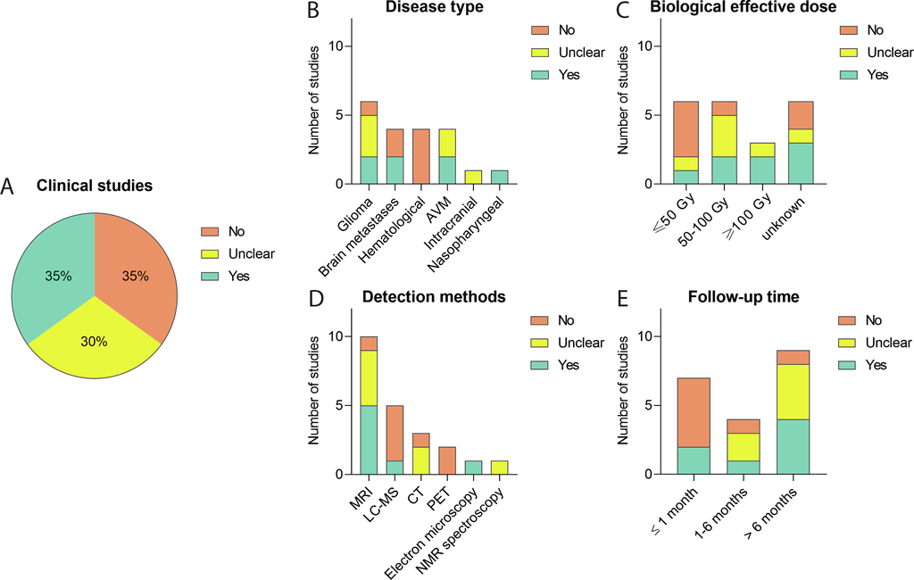

**Fig. 2.** Effect of RT on BBB permeability in clinical studies - qualitative analysis. Analysing clinical studies, the absence or presence of RT-induced BBB permeability

was evaluated (A) and subgrouped by disease type (B), Biological effective dose (C), BBB disruption detection method D), and duration of patient follow-up (E),

showing differential effects.

*E. Hart et al.*

*Clinical and Translational Radiation Oncology 35 (2022) 44–55*

50

patients with low-grade glioma were irradiated, with the same frac-

tionation scheme, cumulative dose, BED, and the same read-out tech-

nique was applied. The three studies with a BED of ≥ 100 Gy used a

single-dose radiation in patients suffering from AVM where RT is used

for stereotactic radiosurgery; Tu et al (2006) [32] and Levegrün et al

(2004) [33] reported a clear BBB disruption, while Parkhutik et al

(2012) [31] only observed this in part of the patients. For the remaining

six studies [34,35,37,39,40,50] no BED could be calculated, because

details on the fractionation scheme applied were not reported. Of these

six studies, three did observe an increased BBB permeability. Two of

these studies, Chan et al (1999) [39] and Lim et al (2018) [40] used a

cumulative dose between 61 and 80 Gy observed increased BBB

breakdown after radiation. Looking at the fractionation scheme Farjam

et al (2015) [41] was the only one of five studies with a fraction dose

below 2 Gy that observed a significant increase in BBB permeability after

1 month of radiation, while Cao et al (2009) [44] reported temporal

changes in the vascular volumes and Gd-DTPA signal in the cerebral

tissue. One of the six studies with a 2 Gy fraction scheme observed a

clear increase BBB permeability after RT, in contrast to Cao et al (2005)

[43] who noticed only a BBB permeability difference close to the

tumour. Qin et al (1990) [46] noted a change but also observed recovery

8 months after radiation; the authors indicated that acute effects can be

reversible and do not necessarily result in permanent damage.

Remarkably, Jarden et al (1985) described 6 Gy per fraction without any

BBB alterations, albeit in combination with dexamethasone [49].

*Detection method*

Five [33,39–41,47] of the ten studies using magnetic resonance

imaging

(MRI)

measuring

the

enhancement/extravasation

of

gadolinium-DTPA observed a clear change in BBB permeability. Other

studies used a more indirect technique to detect BBB disruption. One

[50] of the five studies using liquid chromatography–mass spectrometry

(LC-MS) to detect drugs in cerebrospinal fluid as a surrogate marker of

BBB disruption noticed a change (Fig. 2D). Fang et al (2015) [48] treated

patients with Gefitinib but did not observe an effect despite a high cu-

an alteration in BBB integrity by electron microscopy, while studies

using computed tomography (CT) or positron emission tomography

(PET) imaging did not detect any effect. Even with a high cumulative

dose of 60 Gy, Matulewicz et al (2006) [42], who used nuclear magnetic

resonance (NMR) spectroscopy, could not draw any clear conclusion but

observed oscillations of choline-containing compounds over time, which

might be indicative of BBB disruption and repair processes.

*Follow-up time*

Two of the seven clinical studies (29%) investigating an acute effect

in BBB permeability after radiotherapy (Fig. 2E) reported changes after

three and four weeks [47,50]. Of the four studies studying early delayed

effects, only Lim et al (2018) observed a clear increase in BBB perme-

ability [40], while Cao et al (2009) [44] and Cao et al (2005) [43] were

unclear In their conclusion but both documented a peak of BBB

permeability for radiation doses greater than 40 and in the range 20 to

40 Gy respectively. Late delayed effects of radiation on the BBB is found

in four of nine studies [32,33,39,41].

*Preclinical data* – *Qualitative analysis*

With respect to the qualitative analysis of the 49 preclinical studies,

38 (78%) reported a clear difference in BBB permeability after RT, six

(12%) detect an unclear effect, and five (10%) did not observe an effect

(Fig. 3A).

*Animal model*

In 55% of the preclinical studies, rats were examined as animal

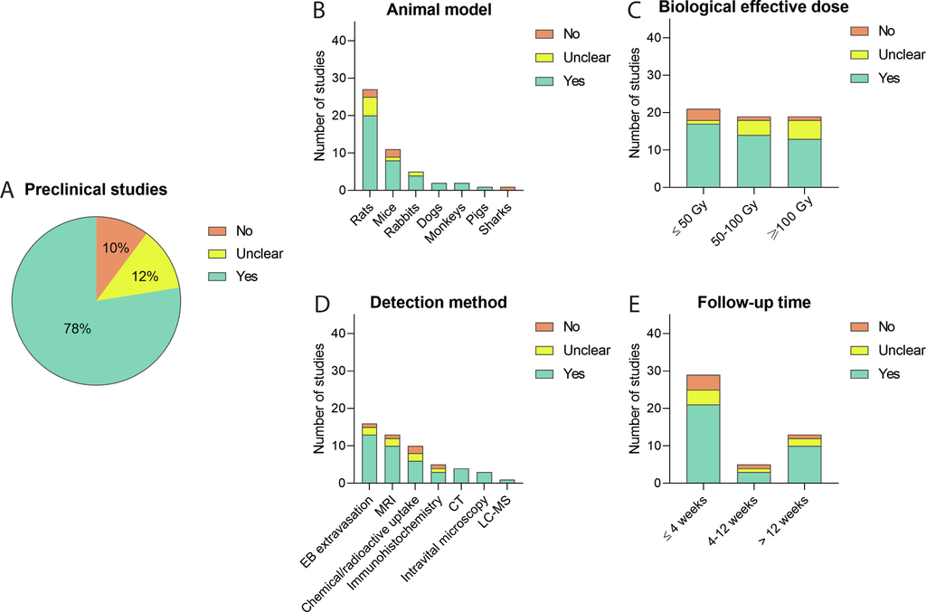

**Fig. 3.** Effect of RT on BBB permeability in preclinical studies - qualitative analysis. Analysing preclinical studies, the absence or presence of RT-induced BBB

permeability was evaluated (A), and subgrouped by animal model used (B), Biological effective dose (C), BBB disruption detection method (D), and duration of

follow-up (E), showing differential effects.

*E. Hart et al.*

*Clinical and Translational Radiation Oncology 35 (2022) 44–55*

51

model. Of these rat studies 74% reported that radiotherapy influenced

the BBB permeability (Fig. 3B). Other animal species were less

frequently used, but permeability changes were also observed in mice,

rabbits, dogs, monkeys, and pigs, but not for sharks. Olsson et al (1972)

concluded that the shark brain is not a suitable model because of its

radio-resistant properties [97]. Of note, Spence et al (1987) [66] and

Bulat (1966) [67] reported an absence of effect on BBB integrity dis-

turbances in rats after a short follow-up time of 24 and 48 h. In addition,

in two mouse studies, no changes were observed in BBB permeability;

Murrell et al (2016) [83] and Lampron et al (2012) [78] noticed no

changes in BBB permeability with a cumulative dose of 20 and 10 Gy

respectively.

*Biological effective dose*

Most of the preclinical studies (81%) with a BED of ≤ 50 Gy reported

an increase of BBB permeability. Comparable effects were observed in

studies using a BED of 50–100 Gy (74%) and ≥ 100 Gy (68%), see

Fig. 3C. Although an overall comparable BED was used, clinical studies

relatively used a higher cumulative dose compared to preclinical

studies, whereas in clinical studies BBB permeability was observed to

lesser extent than in preclinical studies (35% vs 78%). Additionally, the

bulk of the preclinical studies (84%) used a single dose fraction for the

irradiation of the animals, with 76% of these studies observing an

enhanced BBB permeability. When multiple fractionations were applied,

the animals received 2 or up to 10 Gy per fraction, with a cumulative

dose of 6 or up to 40 Gy. Levin et al (1979) [75], applied fractions of 2 or

4 Gy with a cumulative dose up to 30 Gy and detected some permeability

changes, whereas Murrell et al (2016) [83] did not observe any change

after two fractions of 10 Gy with a cumulative dose of 20 Gy.

*Detection method*

Unlike clinical studies, animal research more easily allowed for post-

mortem observations and the usage of multiple detection methods

(Fig. 3D). Interestingly, two of the five studies that did not observe a BBB

integrity issue were analysed by Evans blue extravasation or immuno-

histochemistry [78,97], in which brain surgery and processing was

necessary to acquire the results. When comparing clinical and preclini-

cal studies that use MRI, the results are relatively similar.

*Follow-up time*

For each follow-up time (acute, early delayed, and late delayed) most

preclinical studies observed a relatively equal occurrence of increased

BBB permeability: 72%, 60% and 77%, respectively (Fig. 3E). In

contrast, in clinical studies an increase in BBB permeability was pre-

dominantly reported as late delayed effect.

*Preclinical data* – *Meta-analysis*

The 29 preclinical studies included in the meta-analysis showed a

significant effect of radiation on BBB permeability between irradiated

animals (radiotherapy group) and non-irradiated animals (control

group): −9.92 [-11.89, −7.95] (n = 29, p *<* 0.01) (Fig. S3). However,

heterogeneity was high (I<sup>2</sup>= 98%).

*Preclinical model*

In the studies included in the meta-analysis, in both mice (34%) and

rats (55%), RT significantly increased BBB permeability (mice SMD

−10.97 [-15.77, −6.18], n = 10, p *<* 0.01; rats- SMD 8.79 [-11.24,

−6.70], n = 16, p *<* 0.01) (Fig. S4). Subgroup analysis did not show any

significant difference between effect estimates in mice and rats (p =

0.26). Heterogeneity in both subgroups was high (I<sup>2</sup>= 98% and I<sup>2</sup>=

98%) in mice and rats, respectively. Moreover, the studies using mon-

keys and rabbits were excluded from the meta-analysis because data was

insufficient to create a subgroup, *i.e.*, group size lower than five.

*Biological effective dose*

A significant effect of radiation on BBB permeability was found in all

the three subgroups of the BED, ≤ 50 Gy, 50–100 Gy and ≥ 100 Gy:

−8.14 [-10.60, −5.69] (n = 15, p *<* 0.01), −11.66 [-15.97, −7.35] (n =

11, p *<* 0.01), and −6.63 [-9.53, −3.74] (n = 8, p *<* 0.01) (Fig. S5). No

significant difference of these effects is found between the three sub-

groups (Chi<sup>2</sup>, p = 0.16). In addition, a substantial heterogeneity was

found in all three subgroups: I<sup>2</sup>= 98%, I<sup>2</sup>= 99%, and I<sup>2</sup>= 97%, indi-

cating a low similarity between studies with similar BEDs.

*Detection method*

Subgroup analysis of the detection methods: Evans blue extravasa-

tion, MRI (gadolinium-DTPA) and extravasation of radioactive tracers

(Fig. S6), showed a significant increase in BBB permeability after radi-

ation: –23.75 [-34.82, −12.69] (n = 7, p *<* 0.01), −6.77 [-9.44, −4.10]

(n = 8, p *<* 0.01) and −8.81 [-14.36, −3.26] (n = 5, p *<* 0.01),

respectively. Comparison of the effect estimates between subgroups

showed a significant difference in BBB permeability (p = 0.01), which

could be ascribed to a difference between the sensitivity of Evans blue

extravasation and MRI (ΔSMD = 16.98, 95% CI −25.38, −8.59) as a

detection method. Heterogeneity was high in each subgroup: I<sup>2</sup>= 98 %,

I<sup>2</sup>= 97% and I<sup>2</sup>= 98% for Evans blue, MRI, or radioactive tracers,

respectively.

*Follow-up time*

The onset of BBB permeability after radiation therapy was explored

with acute, early delayed, and late delayed categories and a significant

increase in BBB permeability is observed in all follow-up time cate-

gories: −7.75 [-9.65, −5.85] (n = 25, p *<* 0.01), −6.06 [-8.83, −3.29]

(n = 7, p *<* 0.01) and −5.79 [-9.07, −2.52] (n = 5, p *<* 0.01), respec-

tively (Fig. S7). For each category, a high heterogeneity was found: I<sup>2</sup>=

98% (, I<sup>2</sup>= 97%, and I<sup>2</sup>= 94%, respectively. No significant difference

between these follow-up time categories was found (p = 0.46).

*Publication bias*

Potential publication bias was assessed for the outcome of BBB

permeability upon RT in the 29 preclinical studies included in the meta-

analysis (Fig. S8). Asymmetry observed in the funnel plot suggests the

presence of publication bias, which was confirmed by Egger’s regression

line. The funnel plot indicates that studies with small cohorts favouring

negative results were missing in the publication record. Trim-and-fill

the effect size. Despite this overestimation, the effect of radiation on BBB

permeability remains significant.

**Discussion**

Conventional photon RT is a therapeutic cornerstone in brain cancer

and it is commonly postulated that this treatment modality alters BBB

permeability [16], a key protective component to maintain brain tissue

homeostasis. The downside of a dysfunctional BBB is that the brain

tissue is more exposed to blood-borne proteins, waste products and

pathogens, potentially resulting in a variation of neurological disorders

such as neuroinflammatory reactions and neurodegenerative diseases

[99–101]. On the other hand, in the context of neurological diseases and

brain cancer, an increased BBB permeability can have therapeutic ad-

vantages, whereby drugs that normally have limited access to the brain

parenchyma are able to better reach the diseased brain [4]. To illustrate,

new upcoming techniques such as focused ultrasound, aim to increase

the BBB permeability locally and transiently for the extravasation of

drugs into the brain parenchyma for the treatment of neurodegenerative

diseases such as Alzheimer’s Diseases and primary brain tumours as well

as brain metastases [102–104]. In scope of the safety of patients and

their (concomitant and adjuvant) treatment, it is crucial to monitor,

*E. Hart et al.*

*Clinical and Translational Radiation Oncology 35 (2022) 44–55*

52

evaluate and control the extent of BBB permeability caused by RT.

However, the factors leading to BBB alteration remain to be better un-

derstood and a thorough analysis of the evidence on RT-induced BBB

disruption thus far has been lacking. This systematic review and meta-

analysis therefore explored the contribution of these determinants in

the state-of-the-art literature. Based on a qualitative analysis of relevant

literature and by performing a meta-analysis, we conclude from pre-

clinical and clinical studies that photon radiotherapy indeed enhances

the permeability of the BBB, although the low level of data-reporting

and likely occurrence of publication bias of the included studies,

limits the strength of these conclusions.

For better comparison between studies, the BED was calculated.

Whereas clinical studies mostly observed BBB permeability upon RT at

≥ 100 Gy, preclinical studies display an overall effect in each of the BED

categories. Most of the preclinical studies used a single dose instead of a

multiple fractionation scheme which is mainly used in the clinical

observed in only 20% of the preclinical studies applying fractionation

protocols at a respectively equal cumulative dose. Another point of in-

terest: laboratory animals are generally given a higher BED given

compared to the patients in the clinical studies. Recently, the use of

proton therapy as an alternative to conventional photon therapy is

gaining popularity. Proton beam RT may possibly overcome the effects

of RT at the BBB to some extent, as proton therapy is characterized by

the highest energy deposition at the point of interest without an exit

dose, hereby lowering the dose in the surrounding healthy tissue [105].

Now an emerging option for paediatric patients, it may herewith reduce

long term side effects at the developing brain. However, to our knowl-

edge, there is still a limited data on the effects of proton therapy on BBB

permeability, we were unable to analyse this in this systematic review

and meta-analysis. Concerning the follow-up time, in clinical studies,

increased BBB permeability was often observed after six-months, which

could be explained by radio-necrosis [106]. In meantime a significant

effect was reported in all post-RT time subcategories in the pre-clinical

studies. Both clinical and preclinical studies mentioned a peak in

permeability a few months after radiation, followed by BBB restoration

afterwards [41,56]. Furthermore, a correlation between longer perme-

ability and increased radiation doses was observed [44,58,72]. Over the

years, the techniques to measure BBB permeability have improved and

are more refined in their measurements. Older clinical studies mostly

did not detect any BBB permeability change while over the years MRI

became more the standard and studies using this technique found the

opposite effect. Older preclinical studies mostly relied only on the

more recent studies using Evans blue measured that BBB permeability is

increased after RT.

The disease type, stage and/or use of different pharmacological

agents are also thought to cause alterations of the BBB and are therefore

likely to be confounding factors in the assessment of RT-induced BBB

alteration. For instance, glioblastoma often exhibits areas of increased

BBB permeability at diagnosis, which is progressive in advanced stages

of the disease [107]. This permeability not only occurs along the disease

course, but is also often characterized, at a specific disease stage, by a

spatial intra-patient heterogeneity owing to the anarchic formation of a

blood-tumour barrier in the case of certain brain cancers [108]. Note-

worthy, also inter-patient heterogeneity induces a significant variability

in the interpretation of permeability data in BBB studies. For example,

clinical studies exploring haematological malignancies did not observe

any permeability indicating the fact that underlying diseases may in-

fluence the extent of BBB permeability, confounded that the cumulative

dose of RT in these studies was lower. Moreover, most of the patients in

the included clinical studies were treated with additional medication,

which could have further compromised or restored BBB integrity

[37,38]. There is evidence that certain pharmacological agents exert an

effect on BBB functioning and structure, for example inducing BBB

permeability by efflux transporter inhibition [109], or by reinforcement,

as reported in studies including dexamethasone [49]. Dexamethasone is

often prescribed to reduce cerebral edema [110] in brain malignancies

by initiating the glucocorticoid receptor-mediated signalling, ultimately

leading to strengthening and restoration of BBB integrity [111]. It is

often assumed that the juvenile brain (especially that of infants) is more

permeable than the adult brain, even though animal and clinical studies

[112–114] observed well-developed tight junctions and similar activity

of transporters. As the juvenile brain is still in development, it can be

hypothesized that it is more prone to damage and collateral effects

[115]. Of the five clinical studies included, three enrolled paediatric

patients but observed no effect on BBB permeability after radiation

[35,36,38].

Our systematic review indicates that preclinical studies reported

more RT-induced BBB permeability than clinical studies: 78% vs 35%,

respectively. Besides the parameters investigated in this review several

more other reasons can explain more the discrepancy: first, preclinical

studies are designed and performed in a more controlled fashion, thus

potentially reducing group variability and, in turn, increase statistical

power and ultimately find significant differences. Second, preclinical

studies give access to more readout modalities, which allows for mul-

tiparametric ascertainment and cross-validation of disease hallmarks, e.

g., albumin extravasation into the brain parenchyma. In contrast, clin-

ical studies mostly use MRI and/or LC-MS of CSF. However, preclinical

protocols often require animal anaesthesia using agents that induce

haemodynamic changes, e.g., isoflurane-induced vasodilation and in-

crease in blood flow, which is directly sensed by the endothelial barrier,

and may activate pathways that potentially modify BBB integrity likely

to generate experimental biases [116]. Nonetheless, clinical modalities,

such as MRI, CT and PET, can be performed in patients without resorting

to the administration of anaesthetics. The ascertainment of BBB leaki-

ness in clinical MRI protocols mainly uses gadolinium chelates whose

extravasation, according to their high molecular weights, is mediated by

tight junctions at a specific disease stage, thus only reflecting the status

of the physical BBB; however, BBB leakiness for smaller sized molecules

is also mediated by its functional counterpart, mainly including trans-

cytosis, which may be upregulated in the course of specific diseases but

cannot be measured by conventional MRI protocols. Drug-PET imaging

after RT, using radioisotopes such as <sup>11</sup>C or <sup>18</sup>F for small molecule drugs

and <sup>89</sup>Zr for monoclonal antibodies allows for visualization of enhanced

brain uptake of these compounds. Based on subgroup analysis of the pre-

clinical studies, Evans blue extravasation shows a significant increase in

BBB permeability compared to MRI and radioactive compounds, which

have a similar effect size and seem to be more related. Conversely, in

case of Evans blue extravasation the results are obtained from post-

mortem tissues, while MRI and radioactive compounds are acquired in

real-time, explaining this discrepancy. The (pre)clinical studies using

MRI show similar results, which might indicate that this technique is

more reliable to determine BBB disruption in both humans and animals.

More preclinical research is therefore needed to study the effect of RT on

BBB disruption for small to large sized molecules.

In our meta-analysis, no clinical subgroup was eligible for further

processing owing to the absence of non-irradiated control groups. All the

eligible subgroups, *i.e.*, including at least five studies, showed a signif-

icant RT-induced BBB permeability. One of the excluded subgroups

human primate study exploring RT-induced BBB permeability reported

non-significant differences in BBB permeability. The allocation of the

follow-up time for the animal models was solely based on rats [27,28],

which might have influenced the outcome of all the other models and

was not specifically established for radiation effects.

Importantly, the majority of the clinical and preclinical studies

scored either a high or unclear risk of bias, affecting the reliability of the

data, but also can cause an over- or underestimation of the results [118].

*E. Hart et al.*

*Clinical and Translational Radiation Oncology 35 (2022) 44–55*

53

In case of the clinical data, bias can be caused by certain ethical con-

siderations, for example patients can be excluded due to deviant base-

line characteristics, which can cause an overestimation of the results.

Lastly, a potential publication bias was detected, and may also explain

the difference found between clinical and preclinical studies in our

qualitative analyses where the percentage of studies reporting an effect

of RT on BBB permeability was higher for the preclinical studies.

Nevertheless, the trim-and-fill analysis confirmed RT-induced BBB

disruption.

**Conclusion and future perspectives**

This systematic review and meta-analysis of the literature demon-

strates that RT influences BBB permeability, although our findings show

that suboptimal study designs and a publication bias in the selected

studies may be the source of an overestimation of the extent of BBB

permeability induced by RT. Worth mentioning, the robust comparison

of the variables between the studies for qualitative and quantitative

analysis makes it even more difficult for any hard conclusions.

Future preclinical and clinical studies using novel readout modalities

should therefore be focused on fully elucidating the extent and timing of

BBB opening induced by RT. These considerations will be key to adjust

and guide treatment planning in treatment regimens that include RT to

the brain. The effect of RT on the BBB in patients can be studied in more

detail and longitudinally during and after radiotherapy, using advanced

MRI and PET studies. Drug imaging with PET after RT, will provide more

insight on possible RT-induced enhancement of drug delivery to the

brain, avoiding toxicity and optimizing concomitant and adjuvant

treatment strategies for an optimal therapeutic index [119].

**Source of support**

The review has been supported by the KWF Young Investigator

Award (KWF 10911, Dr. D.G. van Vuurden.

**Declaration of Competing Interest**

The authors declare that they have no known competing financial

interests or personal relationships that could have appeared to influence

the work reported in this paper.

**Appendix A. Supplementary data**

Supplementary data to this article can be found online at https://doi.

org/10.1016/j.ctro.2022.04.013.

**References**

[1] Abbott NJ, Patabendige AAK, Dolman DEM, Yusof SR, Begley DJ. Structure and

function of the blood-brain barrier. Neurobiol Dis 2010;37:13–25. https://doi.

org/10.1016/j.nbd.2009.07.030.

[2] Lipinski CA, Lombardo F, Dominy BW, Feeney PJ. Experimental and

computational approaches to estimate solubility and permeability in drug

discovery and development settings. Adv Drug Deliv Rev 1997;23(1-3):3–25.

[3] Pardridge WM. The blood-brain barrier: Bottleneck in brain drug development.

NeuroRx 2005;2:3–14. https://doi.org/10.1602/neurorx.2.1.3.

[4] Van Tellingen O, Yetkin-Arik B, De Gooijer MC, Wesseling P, Wurdinger T, De

Vries HE. Overcoming the blood-brain tumor barrier for effective glioblastoma

treatment. Drug Resist Updat 2015;19:1–12. https://doi.org/10.1016/j.

drup.2015.02.002.

[5] De Vries NA, Beijnen JH, Boogerd W, Van Tellingen O. Blood-brain barrier and

chemotherapeutic treatment of brain tumors. Expert Rev Neurother 2006;6:

1199–209. https://doi.org/10.1586/14737175.6.8.1199.

[6] Delaney G, Jacob S, Featherstone C, Barton M. The role of radiotherapy in cancer

treatment: estimating optimal utilization from a review of evidence-based clinical

guidelines. Cancer 2005;104:1129–37. https://doi.org/10.1002/cncr.21324.

[7] Baskar R, Lee KA, Yeo R, Yeoh K-W. Cancer and radiation therapy: current

advances and future directions. Int J Med Sci 2012;9:193–9. https://doi.org/

10.7150/ijms.3635.

[8] Claes A, Idema AJ, Wesseling P. Diffuse glioma growth: a guerilla war. Acta

Neuropathol 2007;114:443–58. https://doi.org/10.1007/s00401-007-0293-7.

[9] Cohen-Jonathan-Moyal <sup>´</sup>E, Vendrely V, Motte L, Balosso J, Thariat J.

Radioresistant tumours: From identification to targeting. Cancer Radiother 2020;

24:699–705. https://doi.org/10.1016/j.canrad.2020.05.005.

[10] O’Connor MM, Mayberg MR. Effects of radiation on cerebral vasculature: A

review. Neurosurgery 2000;46:138–51. https://doi.org/10.1093/neurosurgery/

46.1.138.

[11] Bentzen SM. Preventing or reducing late side effects of radiation therapy:

radiobiology meets molecular pathology. Nat Rev Cancer 2006;6(9):702–13.

[12] Yuan H, Gaber MW, Boyd K, Wilson CM, Kiani MF, Merchant TE. Effects of

fractionated radiation on the brain vasculature in a murine model: Blood-brain

barrier permeability, astrocyte proliferation, and ultrastructural changes. Int J

Radiat Oncol Biol Phys 2006;66:860–6. https://doi.org/10.1016/j.

ijrobp.2006.06.043.

[13] Marchi N, Angelov L, Masaryk T, Fazio V, Granata T, Hernandez N, et al. Seizure-

promoting effect of blood-brain barrier disruption. Epilepsia 2007;48(4):732–42.

[14] Obermeier B, Daneman R, Ransohoff RM. Development, maintenance and

disruption of the blood-brain barrier. Nat Med 2013;19:1584–96. https://doi.

org/10.1038/nm.3407.

[15] Cheng KM, Chan CM, Fu YT, Ho LC, Cheung FC, Law CK. Acute hemorrhage in

late radiation necrosis of the temporal lobe: report of five cases and review of the

literature. J Neurooncol 2001;51:143–50. https://doi.org/10.1023/a:

1010631112015.

[16] Van Vulpen M, Kal HB, Taphoorn MJB, El Sharouni SY. Changes in blood-brain

barrier permeability induced by radiotherapy: Implications for timing of

chemotherapy? (Review). Oncol Rep 2002;9:683–8. https://doi.org/10.3892/

or.9.4.683.

[17] Moher D, Liberati A, Tetzlaff J, Altman DG. Preferred reporting items for

systematic reviews and meta-analyses: the PRISMA statement. J Clin Epidemiol

2009;62:1006–12. https://doi.org/10.1016/j.jclinepi.2009.06.005.

[18] Higgins JPT, Altman DG, Gøtzsche PC, Jüni P, Moher D, Oxman AD, et al. The

Cochrane Collaboration’s tool for assessing risk of bias in randomised trials. BMJ

2011;343:1–9. https://doi.org/10.1136/bmj.d5928.

[19] Hooijmans CR, Rovers MM, De VR, Leenaars M, Ritskes-hoitinga M,

Langendam MW. SYRCLE ’ s risk of bias tool for animal studies. BMC Med Res

Methodol 2014;14:1–9. https://doi.org/10.1186/1471-2288-14-43.

[20] The Nordic Cochrane Centre, The Cochrane Collaboration. Review Manager

(RevMan). Version 5.3. Copenhagen: The Nordic Cochrane Centre, The Cochrane

Collaboration, 2014. n.d.

[21] RStudio Team. RStudio: Integrated Development for R. RStudio 2020.

[22] Kossmeier M, Tran US, Voracek M. Visualizing Meta-Analytic Data with R

Package Metaviz. R Package Version 2020;(3):1.

[23] Egger M, Davey Smith G, Schneider M, Minder C. Bias in meta-analysis detected

by a simple, graphical test. BMJ 1997;315:629–34. https://doi.org/10.1136/

bmj.315.7109.629.

[24] Duval S, Tweedie R. Trim and fill: A simple funnel-plot-based method of testing

and adjusting for publication bias in meta-analysis. Biometrics 2000;56:455–63.

https://doi.org/10.1111/j.0006-341x.2000.00455.x.

[25] Fowler JF. The linear-quadratic formula and progress in fractionated

radiotherapy. Br J Radiol 1989;62:679–94. https://doi.org/10.1259/0007-1285-

62-740-679.

[26] Greene-Schloesser D, Robbins ME, Peiffer AM, Shaw EG, Wheeler KT, Chan MD.

Radiation-induced brain injury: A review. Front Oncol 2012;2:1–18. https://doi.

org/10.3389/fonc.2012.00073.

[27] Wei T, Guo TZ, Li WW, Kingery WS, Clark JD. Acute versus chronic phase

mechanisms in a rat model of CRPS. J Neuroinflammation 2016;13:1–15. https://

doi.org/10.1186/s12974-015-0472-8.

[28] Collins KH, Hart DA, Smith IC, Issler AM, Reimer RA, Seerattan RA, et al. Acute

and chronic changes in rat soleus muscle after high-fat high-sucrose diet. Physiol

Rep 2017;5(10):e13270.

[29] Rasband, W.S., ImageJ, U. S. National Institutes of Health, Bethesda, Maryland,

USA, https://imagej.nih.gov/ij/, 1997-2018. n.d.

[30] DerSimonian R, Laird N. Meta-analysis in clinical trials revisited. Contemp Clin

Trials 2015;45:139–45. https://doi.org/10.1016/j.cct.2015.09.002.

[31] Parkhutik V, Lago A, Aparici F, Vazquez JF, Tembl JI, Guillen L, et al. Late clinical

and radiological complications of stereotactical radiosurgery of arteriovenous

malformations of the brain. Neuroradiology 2013;55(4):405–12.

[32] Tu J, Stoodley MA, Morgan MK, Storer KP. Responses of arteriovenous

malformations to radiosurgery: Ultrastructural changes. Neurosurgery 2006;58:

749–57. https://doi.org/10.1227/01.NEU.0000192360.87083.90.

[33] Levegrün S, Hof H, Essig M, Schlegel W, Debus J. Radiation-induced changes of

brain tissue after radiosurgery in patients with arteriovenous malformations:

Correlation with dose distribution parameters. Int J Radiat Oncol Biol Phys 2004;

59:796–808. https://doi.org/10.1016/j.ijrobp.2003.11.033.

[34] Moraes PauloL, Dias RodrigoS, Weltman E, Giordani AdelmoJ, Benabou S,

Segreto HC, et al. Outcome of cerebral arteriovenous malformations after linear

accelerator reirradiation. Surg Neurol Int 2015;6(1):96.

[35] Riccardi R, Lasorella A, Tartaglia RL, Riccardi A, Servidei T, Mastrangelo R.

Cranial irradiation and cerebrospinal fluid levels of 6-mercaptopurine in children

with acute leukemia. Med Oncol Tumor Pharmacother 1991;8(2):95–8.

[36] Riccardi R, Riccardi A, Lasorella A, Servidei T, Mastrangelo S. Cranial irradiation

and permeability of blood-brain barrier to cytosine arabinoside in children with

acute leukemia. Clin Cancer Res 1998;4:69–73.

[37] Ott RJ, Brada M, Flower MA, Babich JW, Cherry SR, Deehan BJ. Measurements of

blood-brain barrier permeability in patients undergoing radiotherapy and

chemotherapy for primary cerebral lymphoma. Eur J Cancer Clin Oncol 1991;27:

1356–61. https://doi.org/10.1016/0277-5379(91)90009-3.

*E. Hart et al.*

*Clinical and Translational Radiation Oncology 35 (2022) 44–55*

54

[38] Seshadri RS, Ryall RG, Rice MS, Leahy M, Ellis R. The Effect of Cranial Irradiation

on Blood-Brain Barrier Permeability to Methotrexate. J Paediatr Child Health

1979;15:184–6. https://doi.org/10.1111/j.1440-1754.1979.tb01223.x.

[39] Chan Y-L, Leung S-F, King AD, Choi PHK, Metreweli C. Late radiation injury to the

temporal lobes: morphologic evaluation at MR imaging. Radiology 1999;213(3):

800–7.

[40] Lim WH, Choi SH, Yoo R-E, Kang KM, Yun TJ, Kim J-H, et al. Does radiation

therapy increase gadolinium accumulation in the brain?: Quantitative analysis of

T1 shortening using R1 relaxometry in glioblastoma multiforme patients. PLoS

One 2018;13(2):e0192838.

[41] Farjam R, Pramanik P, Aryal MP, Srinivasan A, Chapman CH, Tsien CI, et al. A

radiation-induced hippocampal vascular injury surrogate marker predicts late

neurocognitive dysfunction 2015;93:908–15. https://doi.org/10.1016/j.

ijrobp.2015.08.014.A.

[42] Matulewicz ł, Sok´oł M, Michnik A, Wydma´nski J. Long-term normal-appearing

brain tissue monitoring after irradiation using proton magnetic resonance

spectroscopy in vivo: Statistical analysis of a large group of patients. Int J Radiat

Oncol Biol Phys 2006;66(3):825–32.

[43] Cao Y, Tsien CI, Shen Z, Tatro DS, Ten Haken R, Kessler ML, et al. Use of magnetic

resonance imaging to assess blood-brain/blood-glioma barrier opening during

conformal radiotherapy. J Clin Oncol 2005;23(18):4127–36.

[44] Cao Y, Tsien CI, Sundgren PC, Nagesh V, Normolle D, Buchtel H, et al. Dynamic

contrast-enhanced magnetic resonance imaging as a biomarker for prediction of

radiation-induced neurocognitive dysfunction. Clin Cancer Res 2009;15(5):

1747–54.

[45] Wu GN, Ford JM, Alger JR. MRI measurement of the uptake and retention of

motexafin gadolinium in glioblastoma multiforme and uninvolved normal human

brain. J Neurooncol 2006;77:95–103. https://doi.org/10.1007/s11060-005-

9101-1.

[46] Qin D-X, Zheng R, Tang J, Li J-X, Hu Y-H. Influence of Radiation on the Blood-

Brain Barrier and Optimum Time of Chemotherapy. Radiat Oncol 1990;19(6):

1507–10.

[47] Teng F, Tsien CI, Lawrence TS, Cao Y. Blood–tumor barrier opening changes in

brain metastases from pre to one-month post radiation therapy. Radiother Oncol

2017;125:89–93. https://doi.org/10.1016/j.radonc.2017.08.006.

[48] Fang L, Sun X, Song Yu, Zhang Y, Li F, Xu Y, et al. Whole-brain radiation fails to

boost intracerebral gefitinib concentration in patients with brain metastatic non-

small cell lung cancer: A self-controlled, pilot study. Cancer Chemother

Pharmacol 2015;76(4):873–7.

[49] Jarden JO, Dhawan V, Poltorak A, Posner JB, Rottenberg DA. Positron emission

tomographic measurement of blood-to-brain and blood-to-tumor transport of

82Rb: The effect of dexamethasone and whole-brain radiation therapy. Ann

Neurol 1985;18:636–46. https://doi.org/10.1002/ana.410180603.

[50] Okawa S, Shibayama T, Shimonishi A, Nishimura J, Ozeki T, Takada K, et al.

Success of Crizotinib Combined with Whole-Brain Radiotherapy for Brain

Metastases in a Patient with Anaplastic Lymphoma Kinase Rearrangement-

Positive Non-Small-Cell Lung Cancer. Case Rep Oncol 2018;11(3):777–83.

[51] Khatri A, Gaber MW, Brundage RC, Naimark MD, Hanna SK, Stewart CF, et al.

Effect of radiation on the penetration of irinotecan in rat cerebrospinal fluid.

Cancer Chemother Pharmacol 2011;68(3):721–31.

[52] Ernst-Stecken A, Jeske I, Hess A, R¨odel F, Ganslandt O, Grabenbauer G, et al.

Hypofractionated stereotactic radiotherapy to the rat hippocampus:

Determination of dose response and toleranceHypofraktionierte stereotaktische

Radiotherapie des Hippocampus der Ratte. Normalgewebstoleranz und Dosis-

Wirkungs-Beziehung. Strahlentherapie Und Onkol 2007;183(8):440–6.

[53] Zhou K, Bostr¨om M, Ek CJ, Li T, Xie C, Xu Y, et al. Radiation induces progenitor

cell death, microglia activation, and blood-brain barrier damage in the juvenile

rat cerebellum. Sci Rep 2017;7(1). https://doi.org/10.1038/srep46181.

[54] Fan X-W, Chen Fu, Chen Y, Chen G-H, Liu H-H, Guan S-K, et al.

Electroacupuncture prevents cognitive impairments by regulating the early

changes after brain irradiation in rats. PLoS One 2015;10(4):e0122087.

[55] Cheng L, Ma L, Ren H, Zhao H, Pang Y, Wang Y, et al. Alterations in the

expression of vascular endothelial growth factor in the rat brain following gamma

knife surgery. Mol Med Rep 2014;10:2263–70. https://doi.org/10.3892/

mmr.2014.2520.

[56] Jin X, Liang B, Chen Z, Liu X, Zhang Z. The dynamic changes of capillary

permeability and upregulation of VEGF in rats following radiation-induced brain

injury. Microcirculation 2014;21:171–7. https://doi.org/10.1111/micc.12103.

[57] Guan L, Xia B, Qi X-X, Xu K, Li Z, Zhao Y. Early changes measured by CT perfusion

imaging in tumor microcirculation following radiosurgery in rat C6 brain

gliomas. J Neurosurg 2011;114:1672–80. https://doi.org/10.3171/2011.1.

jns101513.

[58] Zhou H, Liu Z, Liu J, Wang J, Zhou D, Zhao Z, et al. Fractionated radiation-

induced acute encephalopathy in a young rat model: Cognitive dysfunction and

histologic findings. Am J Neuroradiol 2011;32(10):1795–800.

[59] Liu J-L, Tian D-S, Li Z-W, Qu W-S, Zhan Y, Xie M-J, et al. Tamoxifen alleviates

irradiation-induced brain injury by attenuating microglial inflammatory response

in vitro and in vivo. Brain Res 2010;1316:101–11.

[60] Kaya M, Palanduz A, Kalayci R, Kemikler G, Simsek G, Bilgic B, et al. Effects of

lipopolysaccharide on the radiation-induced changes in the blood-brain barrier

and the astrocytes. Brain Res 2004;1019(1-2):105–12.

[61] Yuan H, Gaber MW, McColgan T, Naimark MD, Kiani MF, Merchant TE.

Radiation-induced permeability and leukocyte adhesion in the rat blood-brain

barrier: Modulation with anti-ICAM-1 antibodies. Brain Res 2003;969:59–69.

https://doi.org/10.1016/S0006-8993(03)02278-9.

[62] Krueck WG, Schmiedl UP, Maravilla KR, Spence AM, Starr FL, Kenney J. MR

assessment of radiation-induced blood-brain barrier permeability changes in a rat

glioma model. Am J Neuroradiol 1994;15:625–32.

[63] Mima T, Ogawa Y, Taniguchi T, Toyonaga S, Mori K. Early decrease of P-

glycoprotein in the endothelium of the rat brain capillaries after moderate dose of

irradiation. Neurol Res 1999;21:209–15. https://doi.org/10.1080/

01616412.1999.11740920.

[64] Rubin P, Gash DM, Hansen JT, Nelson DF, Williams JP. Disruption of the blood-

brain barrier as the primary effect of CNS irradiation. Radiother Oncol 1994;31:

51–60. https://doi.org/10.1016/0167-8140(94)90413-8.

[65] D’Avella D, Cicciarello R, Albiero F, Mesiti M, Gagliardi ME, Russi E, et al.

Quantitative Study of Blood-Brain Barrier Permeability Changes after

Experimental Whole- Brain Radiation Experimental 1992;30:1992–8.

[66] Spence AM, Graham MM, O’Gorman LA, Muzi M, Abbott GL, Lewellen TK.

Regional Blood-to-Tissue Transport in an Irradiated Rat Glioma Model. Radiat Res

1987;111(2):225.

[67] Bulat M, Supek Z, Deanovi´c <sup>ˇ</sup>Z. Effect of x-irradiation on the permeability of the

blood-brain barrier for 5-hydroxytryptamine in normal and adrenalectomized

rats. Int J Radiat Biol 1966;11:307–10. https://doi.org/10.1080/

09553006614551141.

[68] Bezek <sup>ˇ</sup>S, Trnovec T, <sup>ˇ</sup>Sˇcasn´ar V, <sup>ˇ</sup>Duriˇsov´a M, Kukan M, K´allay Z, et al. Irradiation

of the head by60Co opens the blood-brain barrier for drugs in rats. Experientia

1990;46(10):1017–20.

[69] Jost G, Frenzel T, Boyken J, Pietsch H. Impact of brain tumors and radiotherapy

on the presence of gadolinium in the brain after repeated administration of

gadolinium-based contrast agents: an experimental study in rats. Neuroradiology

2019;61:1273–80. https://doi.org/10.1007/s00234-019-02256-3.

[70] Delattre JY, Shapiro WR, Posner JB. Acute effects of low-dose cranial irradiation

on regional capillary permeability in experimental brain tumors. J Neurol Sci

1989;90:147–53. https://doi.org/10.1016/0022-510x(89)90097-x.

[71] Karger CP, Hartmann GH, Peschke P, Debus J, Hoffmann U, Brix G, et al. Dose-

response relationship for late functional changes in the rat brain after

radiosurgery evaluated by magnetic resonance imaging. Int J Radiat Oncol Biol

Phys 1997;39(5):1163–72.

[72] Kamiryo T, Kassell NF, Thai QA, Lopes MBS, Lee KS, Steiner L. Histological

changes in the normal rat brain after gamma irradiation. Acta Neurochir (Wien)

1996;138:451–9. https://doi.org/10.1007/BF01420308.

[73] Nakata H, Yoshimine T, Murasawa A, Kumura E, Harada K, Ushio Y, et al. Early

blood-brain barrier disruption after high-dose single-fraction irradiation in rats.

Acta Neurochir (Wien) 1995;136(1-2):82–7.

[74] Omary RA, Berr SS, Kamiryo T, Lanzino G, Kassell NF, Lee KS, et al. Gamma knife

irradition-Induced changes in the normal rat brain studied with 1H magnetic

resonance spectroscopy and imaging. Acad Radiol 1995;2(12):1043–51.

[75] Levin VA, Edwards MS, Byrd A. Quantitative Observations of the Acute Effects of

X-Irradiation on Brain Capillary Permeability: Part 1. Radiat Oncol 1979;5:

1627–31.

[76] Olsson Y, Klatzo I, Carsten A. The effect of acute radiation injury on the

permeability and ultrastructure of intracerebral capillaries. Neuropathol Appl

Neurobiol 1975;1(1):59–68.

[77] Constanzo J, Masson-Cˆot´e L, Tremblay L, Fouquet JP, Sarret P, Geha S, et al.

Understanding the continuum of radionecrosis and vascular disorders in the brain

following gamma knife irradiation: An MRI study. Magn Reson Med 2017;78(4):

1420–31.

[78] Lampron A, Lessard M, Rivest S. Effects of Myeloablation, Peripheral Chimerism,

and Whole-Body Irradiation on the Entry of Bone Marrow-Derived Cells into the

Brain. Cell Transplant 2012;21:1149–59. https://doi.org/10.3727/

096368911X593154.

[79] Wilson CM, Gaber MW, Sabek OM, Zawaski JA, Merchant TE. Radiation-Induced

Astrogliosis and Blood-Brain Barrier Damage Can Be Abrogated Using Anti-TNF

Treatment. Int J Radiat Oncol Biol Phys 2009;74:934–41. https://doi.org/

10.1016/j.ijrobp.2009.02.035.

[80] Nair V, Roth LJ. Effect of X-Irradiation and Certain Other Treatments on Blood

Brain Barrier Permeability. Radiat Res 1964;23:249–64. https://doi.org/

10.2307/3571606.

[81] Yoshida Y, Sejimo Y, Kurachi M, Ishizaki Y, Nakano T, Takahashi A. X-ray

irradiation induces disruption of the blood–brain barrier with localized changes

in claudin-5 and activation of microglia in the mouse brain. Neurochem Int 2018;

119:199–206. https://doi.org/10.1016/j.neuint.2018.03.002.

[82] Kalm M, Bostr¨om M, Sandelius Å, Eriksson Y, Ek CJ, Blennow K, et al. Serum

concentrations of the axonal injury marker neurofilament light protein are not

influenced by blood-brain barrier permeability. Brain Res 2017;1668:12–9.

[83] Murrell DH, Wong E, Jensen MD, Zarghami N, Foster PJ, Chambers AF.

Evaluating Changes to Blood-Brain Barrier Integrity in Brain Metastasis over Time

and after Radiation Treatment. Transl Oncol 2016;9:219–27. https://doi.org/

10.1016/j.tranon.2016.04.006.

[84] Ngen EJ, Wang L, Gandhi N, Kato Y, Armour M, Zhu W, et al. A preclinical murine

model for the early detection of radiation-induced brain injury using magnetic

resonance imaging and behavioral tests for learning and memory: with

applications for the evaluation of possible stem cell imaging agents and therapies.

J Neurooncol 2016;128(2):225–33.

[85] Tamborini M, Locatelli E, Rasile M, Monaco I, Rodighiero S, Corradini I, et al.

A Combined Approach Employing Chlorotoxin-Nanovectors and Low Dose

Radiation to Reach Infiltrating Tumor Niches in Glioblastoma. ACS Nano 2016;10

(2):2509–20.

[86] Tong F, Zhang J, Liu Li, Gao X, Cai Q, Wei C, et al. Corilagin Attenuates

Radiation-Induced Brain Injury in Mice. Mol Neurobiol 2016;53(10):6982–96.

*E. Hart et al.*

*Clinical and Translational Radiation Oncology 35 (2022) 44–55*

55

[87] Zhang J, Tong F, Cai Q, Chen L-J, Dong J-H, Wu G, et al. Shenqi Fuzheng Injection

attenuates irradiation-induced brain injury in mice via inhibition of the NF-κB

signaling pathway and microglial activation. Acta Pharmacol Sin 2015;36(11):

1288–99.

[88] Lo EH, Frankel KA, Steinberg GK, Delapaz RL, Fabrikant JI. High-dose Single-

Fraction Brain Irradiation: MRI, Cerebral Blood Flow, Electrophysiological, and

Histological Studies 1992;22:47–55.

[89] Lo EH, Delapaz RL, Frankel KA, Poljak A, Phillips MH, Brennan KM, et al. MRI

and PET of Delayed Heavy-Ion Radiation Injury in the Rabbit Brain. Radiat Oncol

1991;20:689–96.

[90] Blomstrand C. Dexamethasone effect on blood-brain barrier damage caused by

acute hypertension in x-irradiated rabbits 1975:331–4.

[91] Blomstrand C, Johansson B, Rosengren B. Blood-brain barrier lesions in acute

hypertension in rabbits after unilateral X-ray exposure of brain. Acta Neuropathol

1975;31:97–102. https://doi.org/10.1007/BF00688143.

[92] Kourt´opouios H, Holm SE, Norrby SR. The effects or irradiation and probenecid

on cerebrospinal fluid transport of penicillin. J Antimicrob Chemother 1983;11:

251–5. https://doi.org/10.1093/jac/11.3.251.

[93] Fike JR, Gobbel GT, Mesiwala AH, Shin HJ, Nakagawa M, Lamborn KR, et al.

Cerebrovascular effects of the bradykinin analog RMP-7 in normal and irradiated

dog brain. J Neurooncol 1998;37:199–215. https://doi.org/10.1023/a:

1005874206814.

[94] Gobbel GT, Marton LJ, Lamborn K, Seilhan TM, Fike JR. Modification of

Radiation-Induced Brain Injury by a-Difluoromethylornithine. Radiat Re 1991;

128:306–15.

[95] Tanaka A, Ueno H, Yamashita Y, Caveness WF. Regional Cerebral Blood Flow in

Delayed Brain Swelling Following X-Irradiation of the Right Occipital Lobe in the

Monkey. Brain Res 1975;96(2):233–46.

[96] O’Neill RR, Wakisaka S, Malamut BL. Computer Assisted Tomography of Focal

Cerebral Radiation Necrosis in the Monkey. J Neuropathol Exp Neurol 1977;36

(6):950–5.

[97] Olsson Y, Carsten AL, Klatzo I. Effects of Gamma Radiation on the Shark Brain.

Acta Neuropathol 1972;21:1–10. https://doi.org/10.1007/978-3-319-23162-4_2.

[98] Miot E, Hoffschir D, Pontvert D, Gaboriaud G, Alapetite C, Masse R, et al.

Quantitative Magnetic Resonance and Isotopic Imaging: Early Evaluation of

Radiation Injury to the Braini. Radiat Oncol 1995;32(1):121–8.

[99] Takata F, Nakagawa S, Matsumoto J, Dohgu S. Blood-Brain Barrier Dysfunction

Amplifies the Development of Neuroinflammation: Understanding of Cellular

Events in Brain Microvascular Endothelial Cells for Prevention and Treatment of

BBB Dysfunction. Front Cell Neurosci 2021;15:661838. https://doi.org/10.3389/

fncel.2021.661838.

[100] Erickson MA, Banks WA. Blood-brain barrier dysfunction as a cause and

consequence of Alzheimer’s disease. J Cereb Blood Flow Metab Off J Int Soc

Cereb Blood Flow Metab 2013;33:1500–13. https://doi.org/10.1038/

jcbfm.2013.135.

[101] Sweeney MD, Kisler K, Montagne A, Toga AW, Zlokovic BV. The role of brain

vasculature in neurodegenerative disorders. Nat Neurosci 2018;21:1318–31.

https://doi.org/10.1038/s41593-018-0234-x.

[102] Lipsman N, Meng Y, Bethune AJ, Huang Y, Lam B, Masellis M, et al. Blood-brain

barrier opening in Alzheimer’s disease using MR-guided focused ultrasound. Nat

Commun 2018;9(1). https://doi.org/10.1038/s41467-018-04529-6.

[103] Ishida J, Alli S, Bondoc A, Golbourn B, Sabha N, Mikloska K, et al. MRI-guided

focused ultrasound enhances drug delivery in experimental diffuse intrinsic

pontine glioma. J Control Release 2021;330:1034–45.

[104] Englander ZK, Wei H-J, Pouliopoulos AN, Bendau E, Upadhyayula P, Jan C-I,

et al. Focused ultrasound mediated blood-brain barrier opening is safe and

feasible in a murine pontine glioma model. Sci Rep 2021;11(1). https://doi.org/

10.1038/s41598-021-85180-y.

[105] Kirsch DG, Tarbell NJ. New technologies in radiation therapy for pediatric brain

tumors: the rationale for proton radiation therapy. Pediatr Blood Cancer 2004;42:

461–4. https://doi.org/10.1002/pbc.10471.

[106] Walker AJ, Ruzevick J, Malayeri AA, Rigamonti D, Lim M, Redmond KJ, et al.

Postradiation imaging changes in the CNS: how can we differentiate between

treatment effect and disease progression? Future Oncol 2014;10(7):1277–97.

[107] Sarkaria JN, Hu LS, Parney IF, Pafundi DH, Brinkmann DH, Laack NN, et al. Is the

blood-brain barrier really disrupted in all glioblastomas? A critical assessment of

existing clinical data. Neuro Oncol 2018;20(2):184–91.

[108] Arvanitis CD, Ferraro GB, Jain RK. The blood-brain barrier and blood-tumour

barrier in brain tumours and metastases. Nat Rev Cancer 2020;20:26–41. https://

doi.org/10.1038/s41568-019-0205-x.

[109] Wagner CC, Bauer M, Karch R, Feurstein T, Kopp S, Chiba P, et al. A pilot study to

assess the efficacy of tariquidar to inhibit P-glycoprotein at the human blood-

brain barrier with (R)-11C-verapamil and PET. J Nucl Med 2009;50(12):1954–61.

[110] Kostaras X, Cusano F, Kline GA, Roa W, Easaw J. Use of dexamethasone in

patients with high-grade glioma: a clinical practice guideline. Curr Oncol 2014;

21:e493–503. https://doi.org/10.3747/co.21.1769.

[111] Hue CD, Cho FS, Cao S, Dale Bass CR, Meaney DF, Morrison 3rd B.

Dexamethasone potentiates in vitro blood-brain barrier recovery after primary

blast injury by glucocorticoid receptor-mediated upregulation of ZO-1 tight

junction protein. J Cereb Blood Flow Metab Off J Int Soc Cereb Blood Flow Metab

2015;35:1191–8. https://doi.org/10.1038/jcbfm.2015.38.

[112] Nitta T, Hata M, Gotoh S, Seo Y, Sasaki H, Hashimoto N, et al. Size-selective

loosening of the blood-brain barrier in claudin-5-deficient mice. J Cell Biol 2003;

161(3):653–60.

[113] Johansson PA, Dziegielewska KM, Ek CJ, Habgood MD, Liddelow SA, Potter AM,

et al. Blood-CSF barrier function in the rat embryo. Eur J Neurosci 2006;24(1):

65–76.

[114] Møllgård K, Dziegielewska KM, Holst CB, Habgood MD, Saunders NR. Brain

barriers and functional interfaces with sequential appearance of ABC efflux

transporters during human development. Sci Rep 2017;7:11603. https://doi.org/

10.1038/s41598-017-11596-0.

[115] Saunders NR, Liddelow SA, Dziegielewska KM. Barrier mechanisms in the

developing brain. Front Pharmacol 2012;3:46. https://doi.org/10.3389/

fphar.2012.00046.

[116] Yang S, Gu C, Mandeville ET, Dong Y, Esposito E, Zhang Y, et al. Anesthesia and

surgery impair blood–brain barrier and cognitive function in mice. Front

Immunol 2017;8. https://doi.org/10.3389/fimmu.2017.00902.

[117] Casals JB, Pieri NC, Feitosa ML, Ercolin AC, Roballo KC, Barreto RS, et al. The Use

of Animal Models for Stroke Research: A Review. Comp Med 2011;61:305–13.

https://doi.org/10.1109/TAES.1968.5408692.

[118] Wood L, Egger M, Gluud LL, Schulz KF, Jüni P, Altman DG, et al. Empirical

evidence of bias in treatment effect estimates in controlled trials with different

interventions and outcomes: meta-epidemiological study. BMJ 2008;336(7644):

601–5.

[119] Ghosh KK, Padmanabhan P, Yang C-T, Ng DCE, Palanivel M, Mishra S, et al.

Positron emission tomographic imaging in drug discovery. Drug Discov Today

2022;27(1):280–91.

*E. Hart et al.*